# Телеком

## Содержание:

- Задача
- План проекта
- Предварительный анализ данных
  - Загрузка файлов
  - Датафрейм 'contract'
  - Датафрейм 'personal'
  - Датафрейм 'internet'
  - Датафрейм 'phone'
- Предобработка
  - Объединение датафреймов
  - Целевой признак
  - Преобразование типов
- EDA
  - Категориальные признаки
  - Количественные признаки
  - "Средний портрет" ушедшего и оставшегося пользователей
  - Дисбаланс классов
- Feature Engineering and Feature Selection
  - Синтетические признаки
  - Мультиколлинеарность и корреляции с таргетом
- Обучение моделей
  - Логистическая регрессия
  - Случайный лес
  - CatBoost
- Тестирование
  - Feature Importance
  - Доработка модели
  - Сравнение с Dummy
- Отчет

# Задача

Необходимо обучить **модель для прогнозирования оттока клиентов** оператора связи «Ниединогоразрыва.ком». Если выяснится, что пользователь планирует уйти, ему будут предложены промокоды и специальные условия. В нашем распоряжении данные о контрактах клиентов на 1 февраля 2020 года.

## Цель проекта

Построить модель для **задачи бинарной классификации** клиентов. Для достижения цели необходимо изучить и предобработать данные, провести кросс-валидацию нескольких моделей и протестировать лучшую.

**Метрика качества ROC-AUC** должна быть не менее 0.85. Одновременно необходимо определять метрику accuracy.

# План проекта

Предоставленные данные были предварительно изучены. На основании этого составлен следующий план действий:

1. **Предобработка**. Объединим датафреймы в один. Заполним образовавшиеся пропуски в столбце `'InternetService'` значением `'non user'`, а во всех остальных нулями. Построим столбец-таргет `'Churn'` по столбцу `'EndDate'`. Приведем типы данных.
2. **Подробный EDA**. Проанализируем распределения переменных. Составим "средний портрет" оставшегося и уходящего клиента, исследуем дисбаланс классов.
3. **Feature Engineering и Feature Selection**. Построим синтетические признаки:
   - `'Duration'` по столбцам `'BeginDate'` и `'EndDate'`;
   - `'AdditionalServices'` с количеством дополнительных интернет-сервисов;
   - `'TotalChargesCategory'` с категорией на основе 20%-х квантилей `'TotalCharges'`.

   Проверим признаки на мультиколлинеарность и удалим нерелевантные.
4. **Обучение моделей**. С помощью кросс-валидации сравним модели *логистической регрессии*, *случайного леса* и *градиентного бустинга* с различными гиперпараметрами. Метрика качества *ROC-AUC* должна быть не менее 0.85. Выберем лучшую модель.
5. **Тестирование**. Выведем метрики модели на тестовой выборке, проведем анализ важности признаков. По результатам анализа доработаем модель и проведем повторное тестирование.
6. **Отчет**. Представим результаты работы в соответствии с планом.

Содержание

```python
#!jupyter nbextension install --py widgetsnbextension
```

[output not shown]

```python
#!jupyter nbextension enable --py widgetsnbextension
```

[output not shown]

```python
#!pip install phik
```

```python
#!pip install shap
```

# Предварительный анализ данных

## Загрузка

Загрузим данные и посмотрим на структуру каждого датафрейма. Выведем информацию о каждом датафрейме.

```python
# импорты
import pathlib
import re

import pandas as pd
import numpy as np
import matplotlib.pyplot as plt
import seaborn as sns
from statistics import quantiles

from sklearn.model_selection import train_test_split, cross_val_score, GridSearchCV, RandomizedSearchCV
from sklearn.preprocessing import OneHotEncoder, OrdinalEncoder, StandardScaler
from sklearn.compose import ColumnTransformer
from sklearn.pipeline import Pipeline
from sklearn.metrics import accuracy_score, roc_auc_score

from sklearn.linear_model import LogisticRegression
from sklearn.ensemble import RandomForestClassifier
from catboost import CatBoostClassifier
from sklearn.dummy import DummyClassifier

import phik
import shap
```

```python
RANDOM_STATE = 270223
```

```python
# используем pathlib, чтобы удобнее организовать загрузку файлов локально и в тренажере практикума
# определяем путь к файлу .ipynb
project_path = pathlib.Path().cwd()

# задаем пути для загрузки локально и в тренажере практикума
local_path = project_path / "final_provider"
yp_path = "/datasets/final_provider"

# задаем путь
data_path = local_path if local_path.is_dir() else yp_path
```

```python
# загружаем файлы и сохранаем в датафреймы
contract = pd.read_csv(str(data_path) + "/" + "contract.csv")
personal = pd.read_csv(str(data_path) + "/" + "personal.csv")
internet = pd.read_csv(str(data_path) + "/" + "internet.csv")
phone = pd.read_csv(str(data_path) + "/" + "phone.csv")
```

## Датафрейм `contract`

Выведем первые 5 строк и информацию о датафрейме. Проверим на дубликаты.

```python
# загружаем первые 5 строк
contract.head()
```

|  | customerID | BeginDate | EndDate | Type | PaperlessBilling | PaymentMethod | MonthlyCharges | TotalCharges |
| --- | --- | --- | --- | --- | --- | --- | --- | --- |
| 0 | 7590-VHVEG | 2020-01-01 | No | Month-to-month | Yes | Electronic check | 29.85 | 29.85 |
| 1 | 5575-GNVDE | 2017-04-01 | No | One year | No | Mailed check | 56.95 | 1889.5 |
| 2 | 3668-QPYBK | 2019-10-01 | 2019-12-01 00:00:00 | Month-to-month | Yes | Mailed check | 53.85 | 108.15 |
| 3 | 7795-CFOCW | 2016-05-01 | No | One year | No | Bank transfer (automatic) | 42.30 | 1840.75 |
| 4 | 9237-HQITU | 2019-09-01 | 2019-11-01 00:00:00 | Month-to-month | Yes | Electronic check | 70.70 | 151.65 |

```python
# выводим информацию
contract.info()
```

```
<class 'pandas.core.frame.DataFrame'>
RangeIndex: 7043 entries, 0 to 7042
Data columns (total 8 columns):
 #   Column            Non-Null Count  Dtype
---  ------            --------------  -----
 0   customerID        7043 non-null   object
 1   BeginDate         7043 non-null   object
 2   EndDate           7043 non-null   object
 3   Type              7043 non-null   object
 4   PaperlessBilling  7043 non-null   object
 5   PaymentMethod     7043 non-null   object
 6   MonthlyCharges    7043 non-null   float64
 7   TotalCharges      7043 non-null   object
dtypes: float64(1), object(7)
memory usage: 440.3+ KB
```

```python
# считаем дубликаты
contract.duplicated().sum()
```

```
0
```

В `contract` 7043 объекта. Пропусков и дубликатов нет. В `'TotalCharges'` тип данных `object`, а должен быть `float`. Попробуем преобразовать тип данных.

```python
# используем конструкцию try-except
try:
    contract['TotalCharges'].astype(float)
except ValueError as e:
    print('ValueError:', e)
```

```
ValueError: could not convert string to float: ''
```

В данном столбце содержатся ячейки с пустыми строками `''`. Посмотрим на строки датафрейма с этими значениями.

```python
# выводим строки с "пустыми" 'TotalCharges'
contract[contract['TotalCharges'] == ' ']
```

|  | customerID | BeginDate | EndDate | Type | PaperlessBilling | PaymentMethod | MonthlyCharges | TotalCharges |
| --- | --- | --- | --- | --- | --- | --- | --- | --- |
| 488 | 4472-LVYGI | 2020-02-01 | No | Two year | Yes | Bank transfer (automatic) | 52.55 |  |
| 753 | 3115-CZMZD | 2020-02-01 | No | Two year | No | Mailed check | 20.25 |  |
| 936 | 5709-LVOEQ | 2020-02-01 | No | Two year | No | Mailed check | 80.85 |  |
| 1082 | 4367-NUYAO | 2020-02-01 | No | Two year | No | Mailed check | 25.75 |  |
| 1340 | 1371-DWPAZ | 2020-02-01 | No | Two year | No | Credit card (automatic) | 56.05 |  |
| 3331 | 7644-OMVMY | 2020-02-01 | No | Two year | No | Mailed check | 19.85 |  |
| 3826 | 3213-VVOLG | 2020-02-01 | No | Two year | No | Mailed check | 25.35 |  |
| 4380 | 2520-SGTTA | 2020-02-01 | No | Two year | No | Mailed check | 20.00 |  |
| 5218 | 2923-ARZLG | 2020-02-01 | No | One year | Yes | Mailed check | 19.70 |  |
| 6670 | 4075-WKNIU | 2020-02-01 | No | Two year | No | Mailed check | 73.35 |  |
| 6754 | 2775-SEFEE | 2020-02-01 | No | Two year | Yes | Bank transfer (automatic) | 61.90 |  |

Это строки клиентов, которые только начали обслуживание 1 февраля 2020 года, поэтому у них еще нет невозвратной суммы за оплаченные услуги. В преобработке будет необходимо заполнить эти значения нулями и преобразовать данные в тип `float`.

Наконец, посмотрим, какие значения могут принимать столбцы `'Type'`, `'PaperlessBilling'` и `'PaymentMethod'`.

```python
# выводим уникальные значения в интересующих столбцах
for column in list(contract.columns[3:6]):
    print(f'{column}: {contract[column].unique()}')
```

```
Type: ['Month-to-month' 'One year' 'Two year']
PaperlessBilling: ['Yes' 'No']
PaymentMethod: ['Electronic check' 'Mailed check' 'Bank transfer (automatic)'
 'Credit card (automatic)']
```

Столбцы `'Type'` и `'PaymentMethod'` - категориальные. Значения столбца `'PaperlessBilling'` можно заменить на 0 и 1.

**Целевой признак** можно построить по столбцу `'EndDate'`. Если в нем стоит дата, значит, клиент ушел - значение таргета `1`. Если стоит значение `'No'`, клиент остался - значение таргета `0`.

Содержание

## Датафрейм `personal`

Выведем первые 5 строк и информацию о датафрейме. Проверим на дубликаты.

```python
# загружаем первые 5 строк
personal.head()
```

|  | customerID | gender | SeniorCitizen | Partner | Dependents |
| --- | --- | --- | --- | --- | --- |
| 0 | 7590-VHVEG | Female | 0 | Yes | No |
| 1 | 5575-GNVDE | Male | 0 | No | No |
| 2 | 3668-QPYBK | Male | 0 | No | No |
| 3 | 7795-CFOCW | Male | 0 | No | No |
| 4 | 9237-HQITU | Female | 0 | No | No |

```python
# выводим информацию
personal.info()
```

```
<class 'pandas.core.frame.DataFrame'>
RangeIndex: 7043 entries, 0 to 7042
Data columns (total 5 columns):
 #   Column         Non-Null Count  Dtype
---  ------         --------------  -----
 0   customerID     7043 non-null   object
 1   gender         7043 non-null   object
 2   SeniorCitizen  7043 non-null   int64
 3   Partner        7043 non-null   object
 4   Dependents     7043 non-null   object
dtypes: int64(1), object(4)
memory usage: 275.2+ KB
```

```python
# считаем дубликаты
personal.duplicated().sum()
```

```
0
```

В данном датафрейме также 7043 строк, нет пропусков и дубликатов. Проверим, что все customerID в датафрейме `personal` есть в датафрейме `contract`.

```python
# считаем совпадающие customerID
print('Число совпадающих ID:', len(contract.merge(personal, how='left', on='customerID')))
```

```
Число совпадающих ID: 7043
```

Все индентификаторы клиентов совпадают, проблем при объединении не возникнет. Посмотрим, какие значения принимают остальные переменные.

```python
# выводим уникальные значения в интересующих столбцах
for column in list(personal.columns[1:]):
    print(f'{column}: {personal[column].unique()}')
```

```
gender: ['Female' 'Male']
SeniorCitizen: [0 1]
Partner: ['Yes' 'No']
Dependents: ['No' 'Yes']
```

Столбец `'gender'` - категориальный. Значения в столбцax `'Partner'` и `'Dependents'` можно заменить на 0 и 1.

## Датафрейм `internet`

Выведем первые 5 строк и информацию о датафрейме. Проверим на дубликаты.

```python
# загружаем первые 5 строк
internet.head()
```

|  | customerID | InternetService | OnlineSecurity | OnlineBackup | DeviceProtection | TechSupport | StreamingTV | StreamingMovies |
| --- | --- | --- | --- | --- | --- | --- | --- | --- |
| 0 | 7590-VHVEG | DSL | No | Yes | No | No | No | No |
| 1 | 5575-GNVDE | DSL | Yes | No | Yes | No | No | No |
| 2 | 3668-QPYBK | DSL | Yes | Yes | No | No | No | No |
| 3 | 7795-CFOCW | DSL | Yes | No | Yes | Yes | No | No |
| 4 | 9237-HQITU | Fiber optic | No | No | No | No | No | No |

```python
# выводим информацию
internet.info()
```

```
<class 'pandas.core.frame.DataFrame'>
RangeIndex: 5517 entries, 0 to 5516
Data columns (total 8 columns):
 #   Column            Non-Null Count  Dtype
---  ------            --------------  -----
 0   customerID        5517 non-null   object
 1   InternetService   5517 non-null   object
 2   OnlineSecurity    5517 non-null   object
 3   OnlineBackup      5517 non-null   object
 4   DeviceProtection  5517 non-null   object
 5   TechSupport       5517 non-null   object
 6   StreamingTV       5517 non-null   object
 7   StreamingMovies   5517 non-null   object
dtypes: object(8)
memory usage: 344.9+ KB
```

```python
# считаем дубликаты
internet.duplicated().sum()
```

```
0
```

```python
# выводим уникальные значения в интересующих столбцах
for column in list(internet.columns[1:]):
    print(f'{column}: {internet[column].unique()}')
```

```
InternetService: ['DSL' 'Fiber optic']
OnlineSecurity: ['No' 'Yes']
OnlineBackup: ['Yes' 'No']
DeviceProtection: ['No' 'Yes']
TechSupport: ['No' 'Yes']
StreamingTV: ['No' 'Yes']
StreamingMovies: ['No' 'Yes']
```

Заполним пропуски в столбце `'InternetService'` значением-филлером `'non user'`. Пропуски в остальных столбцах заполним значениями `'No'`. Также в этих столбцах можно заменить значения на 0 и 1.

Содержание

## Датафрейм `phone`

Выведем первые 5 строк и информацию о датафрейме. Проверим на дубликаты.

```python
# загружаем первые 5 строк
phone.head()
```

|  | customerID | MultipleLines |
| --- | --- | --- |
| 0 | 5575-GNVDE | No |
| 1 | 3668-QPYBK | No |
| 2 | 9237-HQITU | No |
| 3 | 9305-CDSKC | Yes |
| 4 | 1452-KIOVK | Yes |

```python
# выводим информацию
phone.info()
```

```
<class 'pandas.core.frame.DataFrame'>
RangeIndex: 6361 entries, 0 to 6360
Data columns (total 2 columns):
 #   Column         Non-Null Count  Dtype
---  ------         --------------  -----
 0   customerID     6361 non-null   object
 1   MultipleLines  6361 non-null   object
dtypes: object(2)
memory usage: 99.5+ KB
```

```python
# считаем дубликаты
phone.duplicated().sum()
```

```
0
```

```python
# выводим уникальные значения в интересующем столбце
print(f'\'MultipleLines\': {phone.MultipleLines.unique()}')
```

```
'MultipleLines': ['No' 'Yes']
```

Заполним пропуски в этом столбце значениями `'No'`, также можно заменить значения столбца на 0 и 1.

Содержание

# Предобработка

## Объединение датафреймов

Объединим датафреймы в один датафрейм `data` и заполним образовавшиеся пропуски значением `'No'`.

```python
# объединяем датафреймы
data = contract.merge(personal, how='left', on='customerID') \
       .merge(internet, how='left', on='customerID') \
       .merge(phone, how='left', on='customerID')
```

```python
# проверяем результат
data.sample()
```

|  | customerID | BeginDate | EndDate | Type | PaperlessBilling | PaymentMethod | MonthlyCharges | TotalCharges | gender | SeniorCitizen | Partner | Dependents | InternetService | OnlineSecurity | OnlineBackup | DeviceProtection | TechSupport | StreamingTV | StreamingMovies | MultipleLines |
| --- | --- | --- | --- | --- | --- | --- | --- | --- | --- | --- | --- | --- | --- | --- | --- | --- | --- | --- | --- | --- |
| 5219 | 3976-NLDEZ | 2020-01-01 | No | Month-to-month | No | Mailed check | 20.6 | 20.6 | Male | 0 | No | No | NaN | NaN | NaN | NaN | NaN | NaN | NaN | No |

```python
# заполняем пропуски
data.fillna('No', inplace=True)
```

```python
# проверяем, что пропусков не осталось
data.isna().sum().sum()
```

```
0
```

## Целевой признак

Построим целевой признак `'Churn'`. Если в столбце `'EndDate'` стоит дата, клиент ушел (`1`). Если значение `'No'`, клиент остался (`0`). Воспользуемся функцией `target_builder`, с помощью которой вернем столбец с целевым признаком.

```python
# функция для построения таргета
def target_builder(end_date):
    if end_date == 'No':
        return 0
    else:
        return 1
```

```python
# применяем функцию к столбцу 'EndDate' и записываем результат в столбец 'Churn'
data['Churn'] = data.EndDate.apply(target_builder)
```

```python
# проверяем результат
data.head()
```

|  | customerID | BeginDate | EndDate | Type | PaperlessBilling | PaymentMethod | MonthlyCharges | TotalCharges | gender | SeniorCitizen | ... | Dependents | InternetService | OnlineSecurity | OnlineBackup | DeviceProtection | TechSupport | StreamingTV | StreamingMovies | MultipleLines | Churn |
| --- | --- | --- | --- | --- | --- | --- | --- | --- | --- | --- | --- | --- | --- | --- | --- | --- | --- | --- | --- | --- | --- |
| 0 | 7590-VHVEG | 2020-01-01 | No | Month-to-month | Yes | Electronic check | 29.85 | 29.85 | Female | 0 | ... | No | DSL | No | Yes | No | No | No | No | No | 0 |
| 1 | 5575-GNVDE | 2017-04-01 | No | One year | No | Mailed check | 56.95 | 1889.5 | Male | 0 | ... | No | DSL | Yes | No | Yes | No | No | No | No | 0 |
| 2 | 3668-QPYBK | 2019-10-01 | 2019-12-01 00:00:00 | Month-to-month | Yes | Mailed check | 53.85 | 108.15 | Male | 0 | ... | No | DSL | Yes | Yes | No | No | No | No | No | 1 |
| 3 | 7795-CFOCW | 2016-05-01 | No | One year | No | Bank transfer (automatic) | 42.30 | 1840.75 | Male | 0 | ... | No | DSL | Yes | No | Yes | Yes | No | No | No | 0 |
| 4 | 9237-HQITU | 2019-09-01 | 2019-11-01 00:00:00 | Month-to-month | Yes | Electronic check | 70.70 | 151.65 | Female | 0 | ... | No | Fiber optic | No | No | No | No | No | No | No | 1 |

5 rows × 21 columns

## Преобразование типов

Преобразуем типы в некоторых столбцах.

```python
# преобразуем тип в 'TotalCharges' к float
data.TotalCharges = pd.to_numeric(data.TotalCharges, errors='coerce') \
                    .fillna(0).astype(float)
```

```python
# преобразуем тип в 'BeginDate' и 'EndDate' к datetime
data.BeginDate = pd.to_datetime(data.BeginDate, format='%Y-%m-%d')
data.EndDate = pd.to_datetime(data.EndDate.replace(to_replace='No',
                                                   value='2020-02-01'),
                              format='%Y-%m-%d %H:%M:%S')

# построим признак 'Duration' с длительностью пользования услугами в днях
data['Duration'] = (data.EndDate.dt.date-data.BeginDate.dt.date) \
                    .dt.days.astype(int)
```

```python
# поменяем в 'InternetService' значения 'No' на 'Not User',
# чтобы удобнее было обрабатывать другие столбцы со значениями 'Yes' и 'No'
data.InternetService = data.InternetService.replace(to_replace='No', value='Not User')
```

```python
# заменим значения 'No' на 0 и 'Yes' на 1
data = data.replace(to_replace={'No': 0, 'Yes': 1})
```

```python
# проверяем
data.head()
```

|  | customerID | BeginDate | EndDate | Type | PaperlessBilling | PaymentMethod | MonthlyCharges | TotalCharges | gender | SeniorCitizen | ... | InternetService | OnlineSecurity | OnlineBackup | DeviceProtection | TechSupport | StreamingTV | StreamingMovies | MultipleLines | Churn | Duration |
| --- | --- | --- | --- | --- | --- | --- | --- | --- | --- | --- | --- | --- | --- | --- | --- | --- | --- | --- | --- | --- | --- |
| 0 | 7590-VHVEG | 2020-01-01 | 2020-02-01 | Month-to-month | 1 | Electronic check | 29.85 | 29.85 | Female | 0 | ... | DSL | 0 | 1 | 0 | 0 | 0 | 0 | 0 | 0 | 31 |
| 1 | 5575-GNVDE | 2017-04-01 | 2020-02-01 | One year | 0 | Mailed check | 56.95 | 1889.50 | Male | 0 | ... | DSL | 1 | 0 | 1 | 0 | 0 | 0 | 0 | 0 | 1036 |
| 2 | 3668-QPYBK | 2019-10-01 | 2019-12-01 | Month-to-month | 1 | Mailed check | 53.85 | 108.15 | Male | 0 | ... | DSL | 1 | 1 | 0 | 0 | 0 | 0 | 0 | 1 | 61 |
| 3 | 7795-CFOCW | 2016-05-01 | 2020-02-01 | One year | 0 | Bank transfer (automatic) | 42.30 | 1840.75 | Male | 0 | ... | DSL | 1 | 0 | 1 | 1 | 0 | 0 | 0 | 0 | 1371 |
| 4 | 9237-HQITU | 2019-09-01 | 2019-11-01 | Month-to-month | 1 | Electronic check | 70.70 | 151.65 | Female | 0 | ... | Fiber optic | 0 | 0 | 0 | 0 | 0 | 0 | 0 | 1 | 61 |

5 rows × 22 columns

```python
# проверяем типы
data.info()
```

```
<class 'pandas.core.frame.DataFrame'>
Int64Index: 7043 entries, 0 to 7042
Data columns (total 22 columns):
 #   Column            Non-Null Count  Dtype
---  ------            --------------  -----
 0   customerID        7043 non-null   object
 1   BeginDate         7043 non-null   datetime64[ns]
 2   EndDate           7043 non-null   datetime64[ns]
 3   Type              7043 non-null   object
 4   PaperlessBilling  7043 non-null   int64
 5   PaymentMethod     7043 non-null   object
 6   MonthlyCharges    7043 non-null   float64
 7   TotalCharges      7043 non-null   float64
 8   gender            7043 non-null   object
 9   SeniorCitizen     7043 non-null   int64
 10  Partner           7043 non-null   int64
 11  Dependents        7043 non-null   int64
 12  InternetService   7043 non-null   object
 13  OnlineSecurity    7043 non-null   int64
 14  OnlineBackup      7043 non-null   int64
 15  DeviceProtection  7043 non-null   int64
 16  TechSupport       7043 non-null   int64
 17  StreamingTV       7043 non-null   int64
 18  StreamingMovies   7043 non-null   int64
 19  MultipleLines     7043 non-null   int64
 20  Churn             7043 non-null   int64
 21  Duration          7043 non-null   int32
dtypes: datetime64[ns](2), float64(2), int32(1), int64(12), object(5)
memory usage: 1.2+ MB
```

Содержание

# EDA

## Категориальные признаки

Построим распределения признаков. Сначала посмотрим, как распределены категориальные признаки с текстовыми значениями.

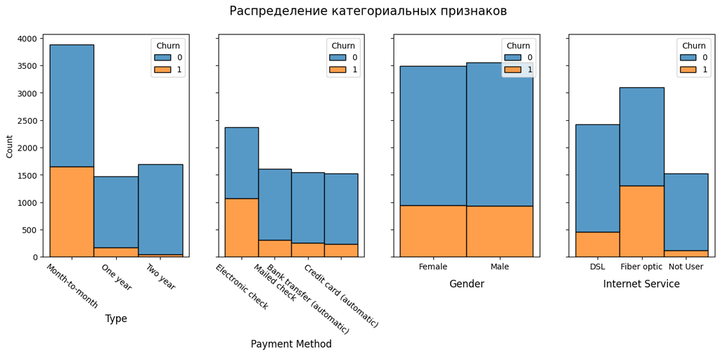

```python
fig, axes = plt.subplots(1, 4, figsize=(15, 5), sharey=True)
plt.suptitle('Распределение категориальных признаков', fontsize=15)

sns.histplot(data, ax=axes[0], x='Type', hue='Churn', multiple="stack")
axes[0].tick_params(axis='x', labelrotation=-40)
axes[0].set_xlabel(xlabel='Type', fontsize=12)

sns.histplot(data, ax=axes[1], x='PaymentMethod', hue='Churn', multiple="stack")
axes[1].tick_params(axis='x', labelrotation=-40)
axes[1].set_xlabel(xlabel='Payment Method', fontsize=12)

sns.histplot(data, ax=axes[2], x='gender', hue='Churn', multiple="stack")
axes[2].set_xlabel(xlabel='Gender', fontsize=12, labelpad=10.0)

sns.histplot(data, ax=axes[3], x='InternetService', hue='Churn', multiple="stack")
axes[3].set_xlabel(xlabel='Internet Service', fontsize=12, labelpad=10.0)

plt.show()
```

**Наблюдения**:

- В признаках `'Type'` и `'InternetService'` в разных категориях доля ушедших пользователей сильно отличается. Эти признаки должны быть полезны для обучения модели. Уходит почти половина пользователей с ежемесячной оплатой. Пользователи с оплатой раз в год или раз в два года уходят значительно реже. Также уходит почти половина пользователей с оптоволоконным интернетом. Возможно, этот способ проведения интернета слишком дорогой (проверим ниже), или есть какие-то проблемы с качеством соединения.
- В признаке `'PaymentMethod'` выделяется значение `'Electronic Check'`. В этой категории доля ушедших пользователей значительно больше, чем в других трех. В других трех категориях доли ушедших пользователей сильно не отличаются, но этот признак отбрасывать не стоит.
- В признаке `'Gender'` примерно равные количества ушедших и оставшихся пользователей. Этот признак кажется не очень полезным.

**Вывод**:

Признаки `'Type'` и `'InternetService'` точно будут полезны для нашей задачи. Признак `'PaymentMethod'` также стоит оставить. Признак `'gender'`, возможно, стоит отбросить.

Теперь посмотрим на распределения "бинарных" признаков.

```python
# список бинарных признаков
columns = []
for column in data.columns:
    if data[column].dtype == 'int64' and column != 'Churn':
        columns.append(column)
```

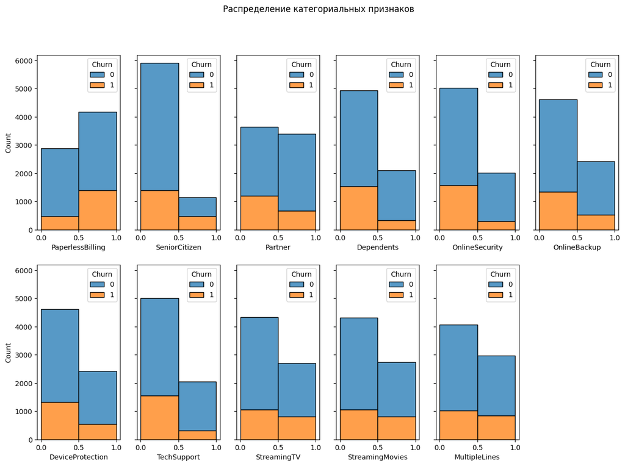

```python
fig, axes = plt.subplots(2, 6, figsize=(15, 10), sharey=True)
plt.suptitle('Распределение категориальных признаков')

for i, column in enumerate(columns):
    sns.histplot(data, ax=axes[i // 6][i % 6], x=column, hue='Churn', multiple="stack", binwidth=0.5)

fig.delaxes(axes.flatten()[11])

plt.show()
```

Наблюдения:

**Вывод**:

Так как признаки с дополнительными услугами имеют похожие распределения, по которым сложно делать выводы, стоит попробовать объединить их в одном признаке с общим количеством дополнительных сервисов, которыми пользуется клиент. Сделаем это на этапе Feature Engineering и Feature Selection и проверим корреляцию этого признака с таргетом.

Содержание

## Количественные признаки

Теперь посмотрим на распределения количественных признаков и на их попарные совместные распределения.

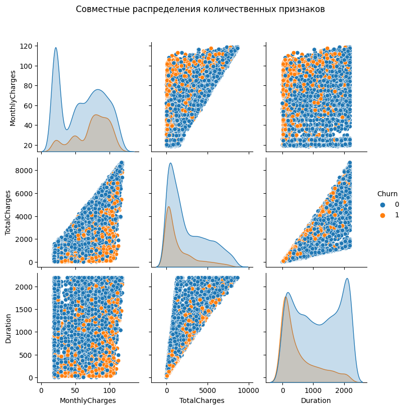

```python
ax = sns.pairplot(data, vars=['MonthlyCharges', 'TotalCharges', 'Duration'],
             hue='Churn', markers='o')
ax.fig.suptitle('Совместные распределения количественных признаков', y=1.08)
plt.show()
```

**Наблюдения**:

- Распределения признака с ежемесячными выплатами `'MonthlyCharges'` заметно отличаются для двух групп. В распределении оставшихся пользователей есть заметный пик, который почти отсутствует в распределении ушедших пользователей.
- Распределения признака с общими выплатами `'TotalCharges'` для двух групп достаточно похожи.
- Распределения признака с длительностью пользования услугами компании `'Duration'` очень сильно отличаются. Можно утвеждать, что чем дольше пользователь является клиентом компании, тем меньше вероятность его ухода.
- Совместное распределение признаков `'TotalCharges'` и `'Duration'` показывает, что эти признаки достаточно сильно скоррелированы.
- В совместном распределении `'TotalCharges'` и `'MonthlyCharges'` также наблюдается некоторая корреляция.
- Признаки `'MonthlyCharges'` и `'Duration'` кажутся нескоррелированными. Кроме того, в их совместном распредлении можно неплохо различить группы ушедших и оставшихся пользователей.

**Вывод**:

Корреляция признака `'TotalCharges'` с признаками `'MonthlyCharges'` и `'Duration'` плохо скажется на работе линейной модели. При использовании линейной модели следует исключить этот признак, т.к. он скоррелирован с двумя другими, которые являются более информативными и нескоррелированными между собой.

Содержание

## "Средний портрет" ушедшего и оставшегося пользователей

Построим, как выглядят признаки среднего оставшегося и ушедшего пользователей.

```python
# датафрейм для удобного представления
client = pd.DataFrame(columns=data.columns, index=[0,1])

# заполняем модой и медианой признаки, сгруппировав по 'Churn'
for i in [0, 1]:
    client.iloc[i] = data.query('Churn == @i').mode().loc[0]
    client.iloc[i][['MonthlyCharges', 'TotalCharges', 'Duration']] = \
        data.query('Churn == @i')[['MonthlyCharges', 'TotalCharges', 'Duration']] \
        .median()
    client.iloc[i]['customerID'] = 'churn ' + str(i)
```

```python
client.drop(['BeginDate', 'EndDate'], axis=1)
```

|  | customerID | Type | PaperlessBilling | PaymentMethod | MonthlyCharges | TotalCharges | gender | SeniorCitizen | Partner | Dependents | InternetService | OnlineSecurity | OnlineBackup | DeviceProtection | TechSupport | StreamingTV | StreamingMovies | MultipleLines | Churn | Duration |
| --- | --- | --- | --- | --- | --- | --- | --- | --- | --- | --- | --- | --- | --- | --- | --- | --- | --- | --- | --- | --- |
| 0 | churn 0 | Month-to-month | 1.0 | Mailed check | 64.425 | 1679.525 | Male | 0.0 | 1.0 | 0.0 | DSL | 0.0 | 0.0 | 0.0 | 0.0 | 0.0 | 0.0 | 0.0 | 0.0 | 1157.0 |
| 1 | churn 1 | Month-to-month | 1.0 | Electronic check | 79.65 | 703.55 | Female | 0.0 | 0.0 | 0.0 | Fiber optic | 0.0 | 0.0 | 0.0 | 0.0 | 0.0 | 0.0 | 0.0 | 1.0 | 304.0 |

**Наблюдения**:

**Выводы**:

Это исследование подтверждает, что признаки `'PaymentMethod'` и `'InternetService'` являются ключевыми. Также подтверждается вывод о корреляции количественных признаков `'TotalCharges'` и `'Duration'`. Так как пол для среднего клиента каждой группы отличается, не будем его сразу отбрасывать, необходимо его также рассмотреть.

## Дисбаланс классов

Исследуем дисбаланс классов.

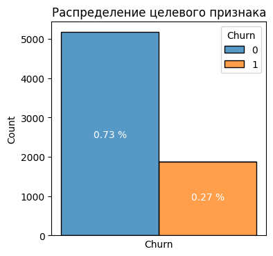

```python
fig = plt.figure(figsize=(4, 4))
ax = sns.histplot(data, x='Churn', hue='Churn', multiple="stack", binwidth=0.5)
ax.text(0.25, 2500, str(1 - data.Churn.mean().round(2)) + ' %',
            color='white', ha='center')
ax.text(0.75, 900, str(data.Churn.mean().round(2)) + ' %',
            color='white', ha='center')
ax.set_title('Распределение целевого признака')
plt.xticks([])
plt.show()
```

Видим, что есть дисбаланс классов. Отношение ушедших пользователей к оставшимся примерно 3:7. Так как для оценки моделей будет использоваться метрика ROC-AUC, которая устройчива к дисбалансу классов, нет необходимости бороться с ним.

### Вывод

Содержание

# Feature Engineering и Feature Selection

Сразу удалим неинформативные колонки: `'customerID'`, `'BeginDate'` и `'EndDate'`.

```python
# удаляем лишние столбцы
data = data.drop(['customerID', 'BeginDate', 'EndDate'], axis=1)
```

## Синтетические признаки

Признак `'Duration'` мы уже добавили, он оказался очень полезным. Теперь добавим новый признак `'AdditionalServices'`, показывающий, сколько дополнительных услуг использовал клиент. Посмотрим на его распределение.

```python
# строим признак 'AdditionalServices'
data['AdditionalServices'] = data[['OnlineSecurity',
                                   'OnlineBackup',
                                   'DeviceProtection',
                                   'TechSupport',
                                   'StreamingTV',
                                   'StreamingMovies',
                                   'MultipleLines']].sum(axis=1)
```

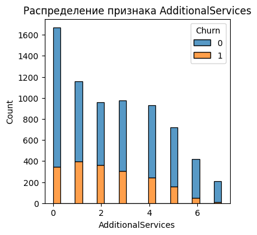

```python
fig = plt.figure(figsize=(4, 4))
ax = sns.histplot(data, x='AdditionalServices', hue='Churn', multiple="stack")
ax.set_title('Распределение признака AdditionalServices')
plt.show()
```

Теперь стала заметна некоторая корреляция с целевым признаком. Среди клиентов, который имеют от 1 до 7 дополнительных услуг доля ушедших клиентов постепенно уменьшается. Численно изучим корреляцию позже.

Количественный признак `'TotalCharges'` оказался не очень удачным, как мы показали ранее. Попробуем построить на его основе категориальный признак `'TotalChargesCategory'` на основе 20-процентных квантилей.

```python
# вычисляем 20%, 40%, 60% и 80% квантили
quan = quantiles(data['TotalCharges'], n=5)

# фукнция для категоризации
def categorize_charges(charges):
    if charges <= quan[0]:
        return 'very low'
    if charges <= quan[1]:
        return 'low'
    if charges <= quan[2]:
        return 'medium'
    if charges <= quan[3]:
        return 'high'
    return 'very high'

# строим признак 'TotalChargesCategory'
data['TotalChargesCategory'] = data['TotalCharges'].apply(categorize_charges)
```

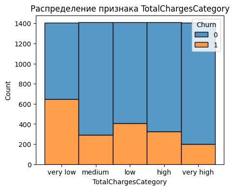

```python
fig = plt.figure(figsize=(5, 4))
ax = sns.histplot(data, x='TotalChargesCategory', hue='Churn', multiple="stack")
ax.set_title('Распределение признака TotalChargesCategory')
plt.show()
```

В каждой категории оказалось примерно одинаковое общее количество клиентов, но доля ушедших клиентов от категории к категории отличается. В общем с увеличением категории затрат доля ушедших клиентов уменьшается. Этот синтенический признак будет удачнее, чем численный `'TotalCharges'`, но нам необходимо проверить его корреляции с другими признаками.

Содержание

## Мультиколлинеарность и корреляция с таргетом

Проверим корреляции признаков друг с другом и с целевым признаком. Посчитаем матрицу корреляции Phik и визуализируем с помощью тепловой карты. Одинаковые ячейки закроем маской, чтобы не перегружать график.

```python
# считаем матрицу коэффициентов корреляции фи-к
phik_corr = data.phik_matrix()
```

```
interval columns not set, guessing: ['PaperlessBilling', 'MonthlyCharges', 'TotalCharges', 'SeniorCitizen', 'Partner', 'Dependents', 'OnlineSecurity', 'OnlineBackup', 'DeviceProtection', 'TechSupport', 'StreamingTV', 'StreamingMovies', 'MultipleLines', 'Churn', 'Duration', 'AdditionalServices']
```

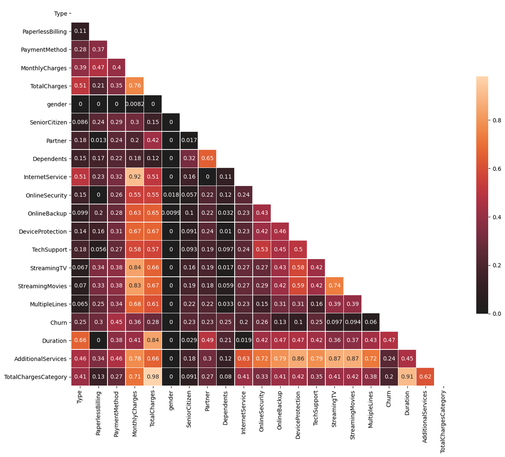

```python
# рисуем heatmap с маской
mask = np.triu(np.ones_like(phik_corr, dtype=bool))
f, ax = plt.subplots(figsize=(15, 15))
sns.heatmap(phik_corr, mask=mask, center=0,
            square=True, linewidths=.5, cbar_kws={"shrink": .5}, annot=True);
```

**Результаты**:

- Целевой признак сильнее всего коррелирует с признаками `'PaymentMethod'` и `'Duration'`. Также есть заметная корреляция с признаками `'PaperlessBilling'` и `'MonthlyCharges'`. Совсем бесполезным оказался признак `'gender'`, как мы и предполагали по результатам EDA. Также практически нет корреляции с большинством признаков с дополнительными услугами. Их все можно смело заменить одним признаком `'AdditionalServices'`.
- Признаки `'TotalChargesCategory'` и `'TotalCharges'`, как и ожидалось, сильно коррелируют с `'MonthlyCharges'` и `'Duration'`. Судя по ранее рассмотренным совместным распределениям признака, корреляция линейная. Для линейной модели стоит отказаться от первых, так как линейные модели плохо реагируют на мультиколлинеарные признаки.
- Ожидаемо есть сильная корреляция между признаком `'AdditionalServices'` и всеми признаками-дополнительными услугами, из которых он строился. Так как мы заменим их все этим одним признаком, можно не беспокоиться.
- Есть достаточно сильная корреляция между признаком `'AdditionalServices'` и признаками `'MonthlyCharges'`. Необходимо проверить, является ли она линейной.

Перед тем, как принимать окончательные решения, проверим линейную корреляция признаков `'TotalCharges'`, `'MonthlyCharges'`, `'Duration'` и `'AdditionalServices'`

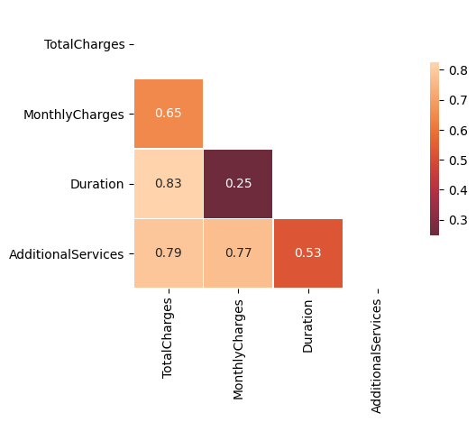

```python
# считаем коэффициенты корреляции Пирсона
pirs_corr = data[['TotalCharges', 'MonthlyCharges', 'Duration', 'AdditionalServices']].corr()

# рисуем heatmap с маской
mask = np.triu(np.ones_like(pirs_corr, dtype=bool))
f, ax = plt.subplots(figsize=(5, 5))
sns.heatmap(pirs_corr, mask=mask, center=0,
            square=True, linewidths=.5, cbar_kws={"shrink": .5}, annot=True);
```

Подтвердилась сильная линейная корреляция между признаком `'TotalCharges'` и признаками `'MonthlyCharges'` и `'Duration'`. Также подтвердилась сильная линейная корреляция между признаками `'MonthlyCharges'` и `'AdditionalServices'`. При обучении линейной модели признаки `'TotalCharges'` (и, соответственно, `'TotalChargesCategory'`) и `'AdditionalServices'` необходимо отбросить. При обучении "деревянных" моделей мультиколлинеарность не должна серьезно повлиять на результат предсказания, но она может замедлить обучение модели и повлиять на интерпретируемость (анализ feature importance).

### Вывод

1. Целевой признак наиболее скоррелирован с признаками `'PaymentMethod'`, `'Duration'`, `'PaperlessBilling'` и `'MonthlyCharges'`. Эти признаки необходимо оставить.
2. Признак `'gender'`, так же как и большинство признаков-дополнительных услуг слабо скоррелированы с целевым признаком, поэтому их можно отбросить.
3. При обучении линейной модели необходимо отказаться от признаков `'TotalCharges'` (`'TotalChargesCategory'`) и `'AdditionalServices'` из-за их сильной линейной корреляции с другими полезными признаками.

Содержание

# Обучение моделей

Подготовим признаки и таргет для "деревянных моделей", для линейной модели удалим лишние признаки позже.

```python
# Выделяем признаки и таргет
X = data[['Type', 'PaperlessBilling', 'PaymentMethod',
          'MonthlyCharges', 'SeniorCitizen', 'Partner',
          'Dependents', 'Duration', 'TotalChargesCategory', 'AdditionalServices']]
y = data['Churn']
```

```python
# делим выборки
X_train, X_test, y_train, y_test = train_test_split(X, y, test_size=0.25, random_state=RANDOM_STATE, stratify=y)
```

```python
# проверяем размеры
X_train.shape, X_test.shape
```

```
((5282, 10), (1761, 10))
```

## Логистическая регрессия

Построим пайплайн с предобработкой и моделью логистической регрессии. Все количественные признаки необходимо масштбировать с помощью `StandardScaler`, а категориальные закодировать с помощью `OneHotEncoder`. категориальные признаки со значениями 0 и 1 подготавливать не нужно.

```python
# списки количественных и категориальных признаков
num = ['MonthlyCharges', 'Duration']
categ = ['Type', 'PaymentMethod']
```

```python
# модель
lr = LogisticRegression()

# инструменты предобработки
scaler = StandardScaler()
ohe_encoder = OneHotEncoder(handle_unknown='ignore')

# предобработка
preprocessor_lr = ColumnTransformer([
    ('scaler', scaler, num),
    ('encoder', ohe_encoder, categ)],
    remainder='passthrough')

# финальный пайплайн
pipe_lr = Pipeline([
    ('preprocessor', preprocessor_lr),
    ('lr', lr)
])
```

```python
# сетка параметров
grid_params_lr = [{
    'lr__solver': ['lbfgs', 'liblinear', 'saga'],
    'lr__penalty': ['l2', 'l1']
}]
```

```python
# делаем grid search
lr_estimator = GridSearchCV(estimator=pipe_lr, param_grid=grid_params_lr,
                            scoring='roc_auc', cv=5, n_jobs=-1, verbose=0)

# не забываем исключить мультиколлинеарные признаки
lr_estimator.fit(X_train.drop(['TotalChargesCategory', 'AdditionalServices'], axis=1), y_train)
```

```
One or more of the test scores are non-finite: [0.83413763 0.83415058 0.83413764        nan 0.83415155 0.8341726 ]
```

```
GridSearchCV(cv=5,
             estimator=Pipeline(steps=[('preprocessor',
                                        ColumnTransformer(remainder='passthrough',
                                                          transformers=[('scaler',
                                                                         StandardScaler(),
                                                                         ['MonthlyCharges',
                                                                          'Duration']),
                                                                        ('encoder',
                                                                         OneHotEncoder(handle_unknown='ignore'),
                                                                         ['Type',
                                                                          'PaymentMethod'])])),
                                       ('lr', LogisticRegression())]),
             n_jobs=-1,
             param_grid=[{'lr__penalty': ['l2', 'l1'],
                          'lr__solver': ['lbfgs', 'liblinear', 'saga']}],
             scoring='roc_auc')
```

```python
print(f'Параметры лучшей модели: {lr_estimator.best_params_}')
print(f'ROC-AUC = {lr_estimator.best_score_:.3f}')
```

```
Параметры лучшей модели: {'lr__penalty': 'l1', 'lr__solver': 'saga'}
ROC-AUC = 0.834
```

Лучшая модель логистической регрессии с регуляризацией `penalty='l1'` и алгоритмом `solver='saga'` показала метрику `ROC-AUC = 0.834`. Это ниже необходимого порога, такая модель точно не подойдет.

Содержание

## Случайный лес

Аналогичным образом построим пайплайн с предобработкой и моделью случайного леса. Количественные признаки масштабировать не нужно, категориальные закодируем с помощью `OrdinalEncoder`, так как деревья решений плохо работают с OHE. Категориальные признаки со значениями 0 и 1 подготавливать также не нужно.

```python
# список категориальных признаков
categ = ['Type', 'PaymentMethod', 'TotalChargesCategory']
```

```python
# модель
rfc = RandomForestClassifier(random_state=RANDOM_STATE)

# инструмент предобработки
ord_encoder = OrdinalEncoder(handle_unknown='ignore')

# преодобработка
preprocessor_rfc = ColumnTransformer([
    ('encoder', ord_encoder, categ)],
    remainder='passthrough')

# финальный пайплайн
pipe_rfc = Pipeline([
    ('preprocessor', preprocessor_rfc),
    ('rfc', rfc)
])
```

```python
# сетка параметров
grid_params_rfc = [{
    'rfc__n_estimators': range(100, 401, 100),
    'rfc__criterion': ['gini', 'entropy'],
    'rfc__min_samples_leaf': range(5, 21, 5)}]
```

```python
# делаем grid search
rfc_estimator = GridSearchCV(pipe_rfc, param_grid=grid_params_rfc,
                             scoring='roc_auc', n_jobs=-1, cv=5, verbose=0)
rfc_estimator.fit(X_train, y_train)
```

```
GridSearchCV(cv=5,
             estimator=Pipeline(steps=[('preprocessor',
                                        ColumnTransformer(remainder='passthrough',
                                                          transformers=[('encoder',
                                                                         OrdinalEncoder(handle_unknown='ignore'),
                                                                         ['Type',
                                                                          'PaymentMethod',
                                                                          'TotalChargesCategory'])])),
                                       ('rfc',
                                        RandomForestClassifier(random_state=270223))]),
             n_jobs=-1,
             param_grid=[{'rfc__criterion': ['gini', 'entropy'],
                          'rfc__min_samples_leaf': range(5, 21, 5),
                          'rfc__n_estimators': range(100, 401, 100)}],
             scoring='roc_auc')
```

```python
print(f'Параметры лучшей модели: {rfc_estimator.best_params_}')
print(f'ROC-AUC = {rfc_estimator.best_score_:.3f}')
```

```
Параметры лучшей модели: {'rfc__criterion': 'entropy', 'rfc__min_samples_leaf': 5, 'rfc__n_estimators': 200}
ROC-AUC = 0.857
```

Лучшая модель случайного леса с гиперпараметрами `criterion='entropy'`, `'min_samples_leaf=5'`, `'n_estimators=200'` показала метрику `ROC-AUC = 0.857`. Это значение перешло необходимый порог, но не на много.

Содержание

## Catboost

Модель градиентного бустинга не требует предобработки данных. Необходимо только передать ей список категориальных переменных в параметре `cat_features`.

```python
# модель
cat = CatBoostClassifier(loss_function='Logloss', random_state=RANDOM_STATE,
                         cat_features=categ, iterations=500, silent=True, eval_metric='AUC:hints=skip_train~false')
```

```python
# сетка параметров
grid_params_cat = {'learning_rate': [0.05, 0.1],
                   'depth': range(6, 11, 2)}
```

```python
%%time
# делаем grid search
cat_grid_result = cat.grid_search(grid_params_cat, X=X_train, y=y_train, cv=5, verbose=True,
                          refit=True, search_by_train_test_split=False, plot=True)
```

```
MetricVisualizer(layout=Layout(align_self='stretch', height='500px'))
```

```
Training on fold [0/5]

bestTest = 0.8902002238
bestIteration = 499

Training on fold [1/5]

bestTest = 0.884334758
bestIteration = 499

Training on fold [2/5]

bestTest = 0.9095544919
bestIteration = 499

Training on fold [3/5]

bestTest = 0.9078171024
bestIteration = 499

Training on fold [4/5]

bestTest = 0.8932575479
bestIteration = 499

0:	loss: 0.8970328	best: 0.8970328 (0)	total: 1m 19s	remaining: 6m 39s
Training on fold [0/5]

bestTest = 0.8987484866
bestIteration = 487

Training on fold [1/5]

bestTest = 0.8928234032
bestIteration = 475

Training on fold [2/5]

bestTest = 0.9143041237
bestIteration = 482
```

[output cut: 103 more lines]

```
bestIteration = 211

Training on fold [3/5]

bestTest = 0.9025266937
bestIteration = 499

Training on fold [4/5]

bestTest = 0.8765026694
bestIteration = 436

5:	loss: 0.8818607	best: 0.9040961 (1)	total: 10m 44s	remaining: 0us
CPU times: total: 25min 15s
Wall time: 11min 1s
```

```python
print(f'Параметры лучшей модели: {cat_grid_result["params"]}')
print(f'ROC-AUC = {cat_grid_result["cv_results"]["test-AUC-mean"][499]:.3f}')
```

```
Параметры лучшей модели: {'depth': 6, 'learning_rate': 0.1}
ROC-AUC = 0.904
```

Лучшая модель градиентного бустинга с гиперпараметрами `depth=6`, `learning_rate=0.1` показала метрику `ROC-AUC = 0.904`. Это выше необходимого порога и намного превосходит метрики других моделей.

Судя по логам, количество деревьев `iterations=500` достаточно, так как примерно после 470-490 итерации метрика ухудшается - начинается переобучение. Логи валидации этой модели:

```
Training on fold [0/5]

bestTest = 0.8987484866
bestIteration = 487

Training on fold [1/5]

bestTest = 0.8928234032
bestIteration = 475

Training on fold [2/5]

bestTest = 0.9143041237
bestIteration = 482

Training on fold [3/5]

bestTest = 0.9177144698
bestIteration = 458

Training on fold [4/5]

bestTest = 0.900103553
bestIteration = 498

1:	loss: 0.9040961	best: 0.9040961 (1)
```

### Вывод

Лучшей оказалась модель градиентного бустинга `CatBoostClassifier` с гиперпараметрами:

- максимальная глубина деревьев `depth=6`
- шаг обучения `learning_rate=0.1`
- количество деревьев `iterations=500`

Эта модель на кросс-валидации показала метрику `ROC-AUC = 0.904`. Обучим эту модель на всей тренировочной выборке и протестируем.

Содержание

# Тестирование

Обучим модель на всей тренировочной выборке.

Сделаем предсказания на тестовой выборке и посчитаем метрики `ROC-AUC` и `accuracy`.

```python
model = cat

# делаем предсказания
pred = model.predict(X_test)
pred_proba = model.predict_proba(X_test)
```

```python
print(f'ROC-AUC на тестовой выборке: {roc_auc_score(y_test, pred_proba[:,1]):.2f}')
print(f'Accuracy на тестовой выборке: {accuracy_score(y_test, pred):.2f}')
```

```
ROC-AUC на тестовой выборке: 0.92
Accuracy на тестовой выборке: 0.87
```

## Feature importance

Исследуем важность признаков с помощью библиотеки `shap`.

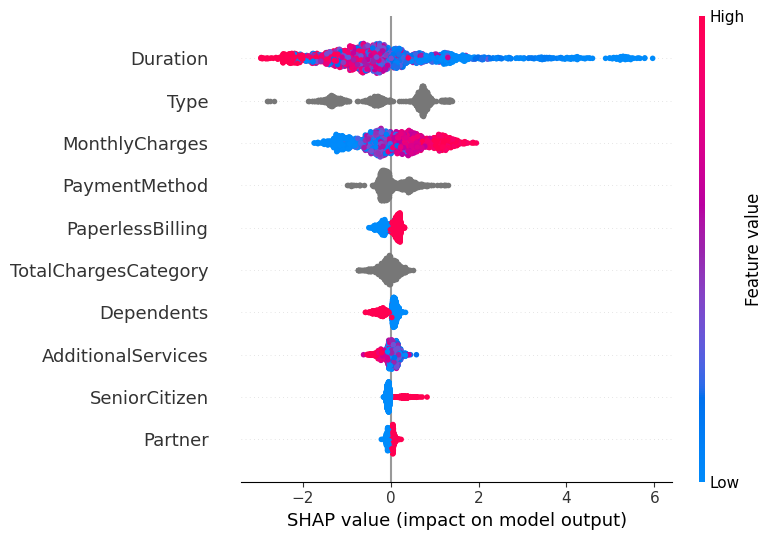

```python
# рисуем график с feature importances
explainer = shap.TreeExplainer(model)
shap_values = explainer.shap_values(X_test)
shap.summary_plot(shap_values, X_test)
```

Выводы о важности признаков `'Duration'`, `'Type'`, `'MonthlyCharges'` и `'PaymentMethod'`, которые были сделаны в EDA, подтвердились. Признаки `'PaperlessBilling'`, `'Dependents'`, `'SeniorCitizen'` и `'Partner'` хотя и имеют меньшую важность, хорошо разделяют классы клиентов. Признаки `'TotalChargesCategory'` и `'AdditionalServices'` имеют небольшую важность, и самое главное, плохо разделяют классы клиентов. Кроме того, они были мультиколлинеарны с другими важными признаками. Попробуем исключить эти два признака и заново обучить и протестировать модель.

## Доработка модели и повторное тестирование

Исключим признаки `'TotalChargesCategory'` и `'AdditionalServices'` из выборок.

```python
# исключаем признаки
X_train = X_train.drop(['TotalChargesCategory', 'AdditionalServices'], axis=1)
X_test = X_test.drop(['TotalChargesCategory', 'AdditionalServices'], axis=1)
```

```python
# модель
new_model = CatBoostClassifier(loss_function='Logloss', random_state=RANDOM_STATE,
                           depth=6, learning_rate=0.1, cat_features=['Type', 'PaymentMethod'], iterations=500, silent=True,
                           eval_metric='AUC:hints=skip_train~false')
# обучаем
new_model.fit(X_train, y_train)
```

```
<catboost.core.CatBoostClassifier at 0x285c58af670>
```

```python
# делаем предсказания
new_pred = new_model.predict(X_test)
new_pred_proba = new_model.predict_proba(X_test)
```

```python
print(f'ROC-AUC на тестовой выборке: {roc_auc_score(y_test, new_pred_proba[:,1]):.2f}')
print(f'Accuracy на тестовой выборке: {accuracy_score(y_test, new_pred):.2f}')
```

```
ROC-AUC на тестовой выборке: 0.92
Accuracy на тестовой выборке: 0.87
```

Результат сильно не улучшился, но и не ухудшился. Значит, эти признаки можно исключить, как минимум, чтобы сэкономить вычислительные мощности.

## Сравнение с Dummy Classifier

Проверим адекватность результатов, сравнив с dummy моделью.

```python
# модель dummy с способом заполнения 'stratified'
dummy = DummyClassifier(strategy='stratified', random_state=RANDOM_STATE)

# обучаем
dummy.fit(X_train, y_train)
```

```
DummyClassifier(random_state=270223, strategy='stratified')
```

```python
# делаем предсказания
dummy_pred = dummy.predict(X_test)
dummy_pred_proba = dummy.predict_proba(X_test)
```

```python
print(f'Dummy ROC-AUC на тестовой выборке: {roc_auc_score(y_test, dummy_pred_proba[:,1]):.2f}')
print(f'Dummy Accuracy на тестовой выборке: {accuracy_score(y_test, dummy_pred):.2f}')
```

```
Dummy ROC-AUC на тестовой выборке: 0.50
Dummy Accuracy на тестовой выборке: 0.60
```

Метрики dummy модели намного ниже порога и тем более метрик нашей модели.

### Вывод

1. Модель градиентного бустинга `CatBoostClassifier`, обученная на всей тренировочной выборке, на тестовой выборке показала метрики:
   - `ROC-AUC = 0.92`
   - `accuracy = 0.87`

   Порог метрики `ROC-AUC больше 0.85` был преодолен.
2. При исследовании feature importance наиболее полезными оказались признаки `'Duration'`, `'Type'`, `'MonthlyCharges'` и `'PaymentMethod'`. Это подтверждает результаты EDA. Признаки `'TotalChargesCategory'` и `'AdditionalServices'` имели маленькую важность и плохо разделяли классы клиентов.
3. После удаления признаков `'TotalChargesCategory'` и `'AdditionalServices'` и повторного обучения и тестирования модели, метрики качества остались на том же уровне. Эти признаки несущественны для задачи, их можно удалить, чтобы сэкономить вычислительные ресурсы.
4. Модель прошла проверку на адекватность при сравнении с dummy классификатором.

Содержание

# Отчет

Необходимо было построить модель для прогнозирования оттока клиентов оператора связи «Ниединогоразрыва.ком». В нашем распоряжении были данные о клиентах оператора до 1 февраля 2020 года. Данные были представлены в четырех отдельных таблицах, содержащих:

- `contracts` - информацию о договорах;
- `personal` - личную информацию клиентов;
- `internet` - информацию об услугах интернет;
- `phone` - информацию об услугах телефонной связи.

**Целью работы** было обучение модели для решения задачи бинарной классификации. **Метрика качества** ROC-AUC должна быть не менее 0.85 на тестовой выборке.

Для достижения поставленной цели были проделаны следующие шаги:

1. **Предобработка**. Все данные были обединены в один датафрейм. Не все клиенты пользовались одновременно интернет- и телефонной связью, образовавшиеся в результате этого пропуски были заполнены надлежащим образом. Целевой признак `'Churn'` был построен по столбцу, содержащему информацию о дате окончания пользования услугами.
2. **Разведовательный анализ**. Был произведен анализ распределений переменных. Анализ показал, что:
   - Среди категориальных признаков самыми важными являются тип оплаты `'PaymentMethod'`, вид интернет-подключения `'InternetService'` и вид контракта `'Type'`.
   - Из признаков с дополнительными услугами необходимо было построить синтетический признак, который их объединит.
   - Была обнаружена заметная корреляция общих выплат `'TotalCharges'` с ежемесячными выплатами `'MonthlyCharges'` и длительностью пользования услугами `'Duration'`.
   - Был обнаружен дисбаланс классов целевого признака. Устранение дисбаланса не потребовалось благодаря устойчивости к нему метрики.
3. **Feature Engineering и Feature Selection**. Были построены синтетические признаки:
   - `'Duration'` по столбцам `'BeginDate'` и `'EndDate'`;
   - `'AdditionalServices'` с количеством дополнительных интернет-сервисов;
   - `'TotalChargesCategory'` с категорией на основе 20%-х квантилей `'TotalCharges'`.

   Были изучены корреляции всех признаков. Анализ коллеряции показал, что:
   - Целевой признак наиболее скоррелирован с признаками `'PaymentMethod'`, `'Duration'`, `'PaperlessBilling'` и `'MonthlyCharges'`.
   - Пол клиента `'gender'`, так же как и большинство признаков-дополнительных услуг слабо скоррелированы с целевым признаком.
   - Признаки `'TotalCharges'` (`'TotalChargesCategory'`) и `'AdditionalServices'` имеют сильную линейную корреляцию с другими полезными признаками.

   Было принято решение оставить для обучения моделей признаки: `'Type'`, `'PaperlessBilling'`, `'PaymentMethod'`, `'MonthlyCharges'`, `'SeniorCitizen'`, `'Partner'`, `'Dependents'`, `'Duration'`, `'TotalChargesCategory'`, `'AdditionalServices'`. При обучении логистической регрессии последние два признака исключались из-за мультиколлинеарности.
4. **Обучение моделей**. Все данные были разделены на обучающую и тестовую выборки в отношении 3:1. Была проведена кросс-валидация на 5 фолдах трех моделей. Предобработка и модели были объединены в пайплайны.
   - *Логистическая регрессия* `LogisticRegression` библиотеки `sklearn`. Количественные признаки масштабировались с помощью `StandardScaler`, категориальные кодировались с помощью `OneHotEncoder`. Исследовались модели с алгоритмами `'lbfgs'`, `'liblinear'`, `'saga'` и регуляризацией `'l2'` и `'l1'`. Лучшая модель с алгоритмом `'saga'` и резуляризацией `'l1'` показала метрику ниже порога `ROC-AUC = 0.834`.
   - *Случайный лес* `RandomForestClassifier` библиотеки `sklearn`. Категориальные признаки кодировались с помощью `OrdinalEncoder`. Исследовались модели с различным количеством деревьев, минимальным количеством объектов в листьях и критериями ветвления `'gini'` и `'entropy'`. Лучшая модель с критерием `'entropy'` и гиперпараметрами `'min_samples_leaf=5'`, `'n_estimators=200'` показала метрику немного выше порога `ROC-AUC = 0.857`.
   - *Градиентный бустинг* `CatBoostClassifier` библиотеки `catboost`. Список категориальных признаков передавался непосредственно в параметрах модели. Иссследовались модели с разным шагом обучения и максимальной глубиной деревьев. Лучшая модель с гиперпараметрами `learning_rate=0.1` и `depth=6` показала метрику выше порога `ROC-AUC = 0.904`.

   Лучшей стала ***модель градиентного бустинга*** `CatBoostClassifier` с гиперпараметрами `learning_rate=0.1` и `depth=6`.
5. **Тестирование**. Модель градиентного бустинга на тестовой выборке показала метрики `ROC-AUC = 0.92` и `accuracy = 0.87`. Порог по метрике был преодолен. Анализ значимости признаков показал, что признаки `'TotalChargesCategory'` и `'AdditionalServices'` оказались незначительными. Модель, обученная без этих признаков показала такие же метрики качества, как и с ними. Сравнение с dummy моделью подтвердило адекватность оценок.

## Вывод

Для решения задачи бинарной классификации была обучена модель градиентного бустинга `CatBoostClassifier` с гиперпараметрами `learning_rate=0.1` и `depth=6`, с помощью которой можно прогнозировать вероятность ухода клиента оператора связи.

На тестовой выборке модель имеет метрику качества `ROC-AUC = 0.92`, которая значительно превосходит пороговое значение 0.85.

Содержание